# advanced_sr

### 2.4 Fitting E-P without outliers

We now have a (slightly) improved E-P fit that we can use to build a better SR score. Because we want to manipulate the data as little as possible (but as much as necessary), we may not want to alter our original data. A more elegant solution can be to use the winsorized scores / outlier exclusion only to extract the E-P intercept and slope - but then apply them on the unaltered scores to calculate the SR score.

In this way, we can ensure that the E-P model fits best for the majority of values without manipulation the actual data.

#### 2.4.1 extract intercept and slope

Extract the intercept and slope from the multilevel model (E-P from single time points)

```
  Task 2.4.1 Save the intercept and slope from the multilevel model with winsorized data (2.3) in separate objects.
```

```r
intercept.w  <- summary(EP_norm_model_winz)$coefficients[1]
E_slope_winz <- summary(EP_norm_model_winz)$coefficients[2]

E_slope_winz
```

```
## [1] 0.3581029
```

```r
# original slope without winsorizing
E_slope_multi
```

```
## [1] 0.3583524
```

The original slope is slightly steeper than the new one based on winsorized scores

#### 2.4.2 predicted P

We use the extracted intercept and slope to calculate the predicted P based on their E, using a linear equation (y=slope*x+intercept)

The E in the equation needs to be scaled.

```
  Task 2.4.2 Calculate the predicted P based on a linear equation, store it as a variable in the dataset
```

```r
 ds$P_pred.w<- intercept.w  + scale(ds$E)*E_slope_multi
```

#### 2.4.3 SR score

The SR score is then the difference between the actual P and the predicted P, that is the residual of each P to the normative E/P line.

```
  Task 2.4.3 Calculate the difference between actual P and predicted P for each participant, based on intercept + slope for winsorized data
  Correlate this SR score with the non-winsorized SR
```

```r
 ds$SR.w <- scale(scale(ds$P) - ds$P_pred.w)

  cor(ds$SR, ds$SR.w)
```

```
##      [,1]
## [1,]    1
```

### 2.5 Notes on further advanced SR approaches

As the SR score is based on residuals, a well-fitting E-P model is crucial for a reliable score. In this sample the fit was already pretty good (despite some smaller influential cases).

However, depending on your sample and E & P measurements, it is possible that your data are so skewed that you will not be able to derive a well fitting model with the above methods (e.g., when a small subset of subjects are exposed to much more stressors than others, or there is zero-inflation in E because only severe LEs are measured in E). In such cases, you may also consider other approaches to getting a well-fitting E-P line, such as non-linear or data-driven E-P model fitting (see e.g., [Hettwer et al., 2024](https://www.nature.com/articles/s41467-024-50292-2)

Is is also not always necessary to equally weight all stressors included in the SR calculation (which we implicitly do by scaling and then averaging Eg and Ec scores). We generally take the scale-and-sum approach when we have a conceptual reason to include different types of stressors with equal weighting. A more data driven approaches that weight stressors differently and optimize explained variance can also be used - but have their own pitfalls (e.g., conceptual issues or inflated explained variance due to mood congruency effects in some stressor measurements but not others).

In general, many approaches to clean your data and improve measurement accuracy can be used to improve your SR score (e.g., data imputation, excluding subjects with reponse invariance or other suspicious answering patterns, etc. etc.)

## 3 E Severity vs count method

In this sample, we have calculated the SR score using the severity-rated stressors. However, in some situations it can also be helpful to create an SR score based on the mere count of occurence of stressors (stressor count method, SCM)

### 3.1 Count scoring E

```
  Task 3.1a Calculate E sum scores as the mere count of occurence of stressors (i.e., stressors rated > 0) and store as a variable in the dataset
```

```r
#Corona pandmic related stressors:
term <- "CE_"
CE <- grep(term, names(ds))
# initiate variable
ds$Ec.SCM <- NA
ds$Ec.SCM <- rowSums(ds[CE] >0, na.rm=TRUE) #stressor count

#general stressors:
term <- "GE_"
GE <- grep(term, names(ds))
ds$Eg.SCM <- NA
ds$Eg.SCM <- rowSums(ds[GE] >0, na.rm=TRUE) #stressor count
```

```
  Task 3.1b Calculate combined E score (based on scaled Ec.SCM and Eg.SCM) and save in a separate variable
```

```r
  ds <- ds  %>%
  ungroup %>%
  # here we are scaling across all time points and all participants
  mutate(Eg_scaled.SCM= scale(Eg.SCM),
         Ec_scaled.SCM=scale(Ec.SCM)) %>%
dplyr::group_by(subject.ID) %>%
  # because we are creating the mean by rows and not by column
  rowwise() %>%
  dplyr::mutate(E_scaled.SCM=mean(c(Eg_scaled.SCM,Ec_scaled.SCM),na.rm = T))%>%
  # this is important to make revert the rowise operator
  ungroup %>%
  dplyr::group_by(subject.ID)
```

```
  Task 3.1c Correlate E scores and E SCM scores to check how much they differ
```

```r
# Corona pandmic related stressors:
cor(ds$Ec.SCM, ds$Ec, use="pairwise.complete.obs")
```

```
## [1] 0.8869013
```

```r
# general stressors:
cor(ds$Eg.SCM, ds$Eg, use="pairwise.complete.obs")
```

```
## [1] 0.8751801
```

```r
# combined scaled score:
cor(ds$E_scaled.SCM, ds$E_scaled, use="pairwise.complete.obs")
```

```
## [1] 0.8823667
```

All scores correlate highly but not perfectly

### 3.2 SR based on count scores

```
  Task 3.2a Use the E count score to fit the E-P line (multilevel model), extract the intercept and slope and compare to the original slope (E_slope_multi)
```

```r
# Re-fit the E-P model
EP_norm_model_scm <- ds %>%
  group_by(subject.ID) %>%

    # specify a model with a random effect for each subject
  lme4::lmer(scale(P)~scale(E_scaled.SCM)+ (1+scale(E_scaled.SCM)|subject.ID),data=.)


intercept.scm <- summary(EP_norm_model_scm)$coefficients[1]
E_slope.scm <- summary(EP_norm_model_scm)$coefficients[2]

E_slope.scm
```

```
## [1] 0.2420197
```

```r
# compare to original slope
E_slope_multi
```

```
## [1] 0.3583524
```

The slope based on severity scoring is a lot steeper than the one fit based on SCM, reflecting the stronger relationship to P

```
  Task 3.2b Calculate SR score based on count score and compare with original severity based score
```

```r
ds$P_pred.scm <- intercept.scm  + scale(ds$E_scaled.SCM)*E_slope.scm

ds$SR.SCM <- scale(scale(ds$P) - ds$P_pred.scm)

cor(ds$SR.SCM, ds$SR)
```

```
##           [,1]
## [1,] 0.9800842
```

Both SR scores are very highly correlated.

```
  Task 3.2c Plot correlations between count based E, Severity based E, P, and SR based on both E measures
```

```r
# here we just calculate all the different correlations
ds %>%
  ungroup() %>%
  select(E_scaled, E_scaled.SCM, P, SR, SR.SCM) %>%
  cor(., use="pairwise.complete.obs")
```

```
##               E_scaled E_scaled.SCM         P         SR    SR.SCM
## E_scaled     1.0000000   0.88236672 0.5194342 0.19057271 0.3259370
## E_scaled.SCM 0.8823667   1.00000000 0.3674008 0.06359201 0.1336008
## P            0.5194342   0.36740077 1.0000000 0.93517597 0.9708100
## SR           0.1905727   0.06359201 0.9351760 1.00000000 0.9800842
## SR.SCM       0.3259370   0.13360075 0.9708100 0.98008421 1.0000000
```

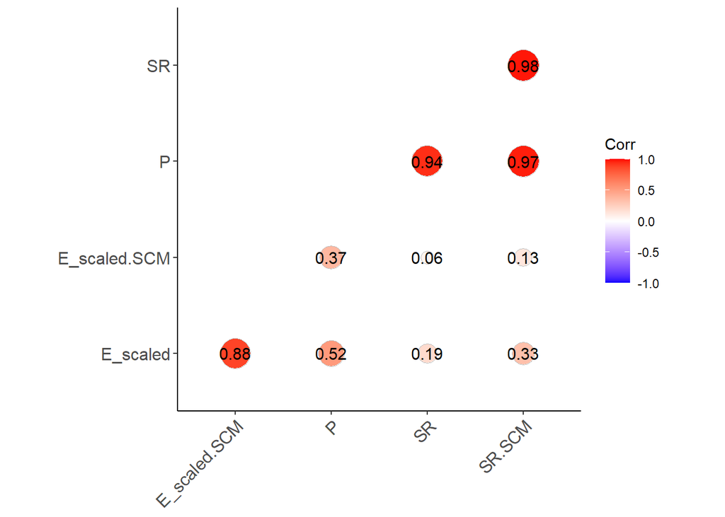

```r
# here we plot the correlations with ggcorrplot
ds %>%
  ungroup() %>%
  select(E_scaled, E_scaled.SCM, P, SR, SR.SCM) %>%
  cor(., use="pairwise.complete.obs")%>%
  ggcorrplot::ggcorrplot(
                          show.legend = TRUE, type="lower", method = "circle", lab=TRUE,
                          ggtheme = ggplot2::theme_classic)
```

Overall, although the coutn based E correlates much less with P, both SR scores (SCM and Severity based) are highly correlated.

In general, the severity ratings include an element of personal stressor appraisal that may confound later relationship with resilience factors, such as positive appraisal style. Therefore, the use of the count based method is preferred whenever stressors are measured comprehensively. However, when only a subset of stressors is measured for brevity (as was the case in DynaCORE-L), including the severity ratings in the scores can help capture stressors more comprehensively.

This rationale is also explained in detail in the supplements of [Veer et al., 2021](https://pubmed.ncbi.nlm.nih.gov/33479211/)